# Sales data analysis

Abhinav Malasi

11/12/2021

# Objective

Analyze the monthly sales data for an year and identify:

1. The month with most sales
2. The best selling product - overall and monthly
3. Time (month of the year, day of the week, hour of the day) when sales peaked and the corresponding products
4. Low sales products
5. State that contributed to the maximum revenue
6. Contributions of the different cities
7. Number of unique invoices

# Approach

1. Load the CSV files
2. Concatenate the files
3. Data augmentation
4. Dealing with missing values
5. EDA

## Loading the necessary packages

```r
library(tidyverse)
library(lubridate)
library(DT)
library(qdapRegex)
```

## Loading the files

```r
file_path <- "C:/Users/amalasi/Documents/R/data_analysis/projects/sales_analytics/data"

#temp = list.files(path = file_path, pattern="*.csv")
temp = dir(path = file_path, pattern="*.csv")

temp
```

```
##  [1] "Sales_April_2019.csv"     "Sales_August_2019.csv"
##  [3] "Sales_December_2019.csv"  "Sales_February_2019.csv"
##  [5] "Sales_January_2019.csv"   "Sales_July_2019.csv"
##  [7] "Sales_June_2019.csv"      "Sales_March_2019.csv"
##  [9] "Sales_May_2019.csv"       "Sales_November_2019.csv"
## [11] "Sales_October_2019.csv"   "Sales_September_2019.csv"
```

## Reading the files

Order ID type was not consistent among the different files, so col_types usd to force all the columns to character type.

```r
load_data <- function(path) {
  files <- dir(path, pattern = '\\.csv', full.names = TRUE)
  #tables <- lapply(files, read.csv)
  #do.call(rbind, tables)

  files %>%
    map_df(~read_csv(., col_types = list(col_integer(),col_character(),col_integer(),col_double(),col_character(),                                                           col_character())))
}

sales <- load_data("data")
```

## Dealing with missing values

For now the missing values are removed. But ideally, the person responsible for generating the data should be contacted to make sure if it is some error or the data can be removed.

```r
sales_NA <- sales %>% filter(is.na(sales))

sales <- sales %>% filter(!is.na(sales))
```

## Extracting date and time information

Split the string into date and time. Convert the list to a data frame.

```r
aa <- sales$`Order Date` %>% str_split(" ",n=2)

bb = do.call(rbind.data.frame, aa)
colnames(bb) <- c("date","time")

sales_new <- cbind(sales,bb)
```

Convert to date format

```r
sales_new$date <- sales_new$date %>% as.Date("%m/%d/%y")

sales_new$month <- month(sales_new$date)

sales_new$day <- day(sales_new$date)
```

Convert to proper time format

```r
sales_new$time <- sales_new$time %>% hm()
```

## Monthly sales made

```r
sales_monthly <- sales_new %>% group_by(month) %>% summarise(revenue = sum(`Price Each`*`Quantity Ordered`))

avg_sales_per_month <- sum(sales_monthly$revenue)/12
```

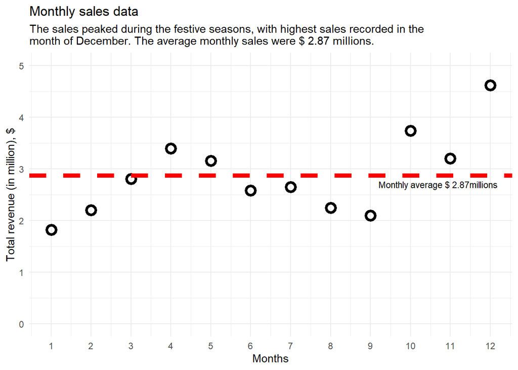

```r
sales_monthly %>% ggplot(aes(month, revenue/1e6)) +
  geom_point(size=3, shape=21, stroke=2) +
  xlab("Months") + ylab("Total revenue (in million), $") +
  scale_x_continuous(breaks=seq(1,12,1)) +
  scale_y_continuous(limits = c(0,5)) +
  geom_hline(yintercept=avg_sales_per_month/1e6, linetype="dashed", color = "red", size=2) +
  annotate("text", x=10.7, y=2.7, label= paste0("Monthly average $ ",round(avg_sales_per_month/1e6,2),"millions"),size=3) +
  labs(title = "Monthly sales data",
       subtitle="The sales peaked during the festive seasons, with highest sales recorded in the \nmonth of December. The average monthly sales were $ 2.87 millions.") +
  theme_minimal()
```

A pattern of sales revenue aligns with the holiday season (Halloween, Christmas, Easter?).

### Sales made on which days of the month

```r
sales_day <- sales_new %>% group_by(day) %>% summarise(revenue = sum(`Price Each`*`Quantity Ordered`))
```

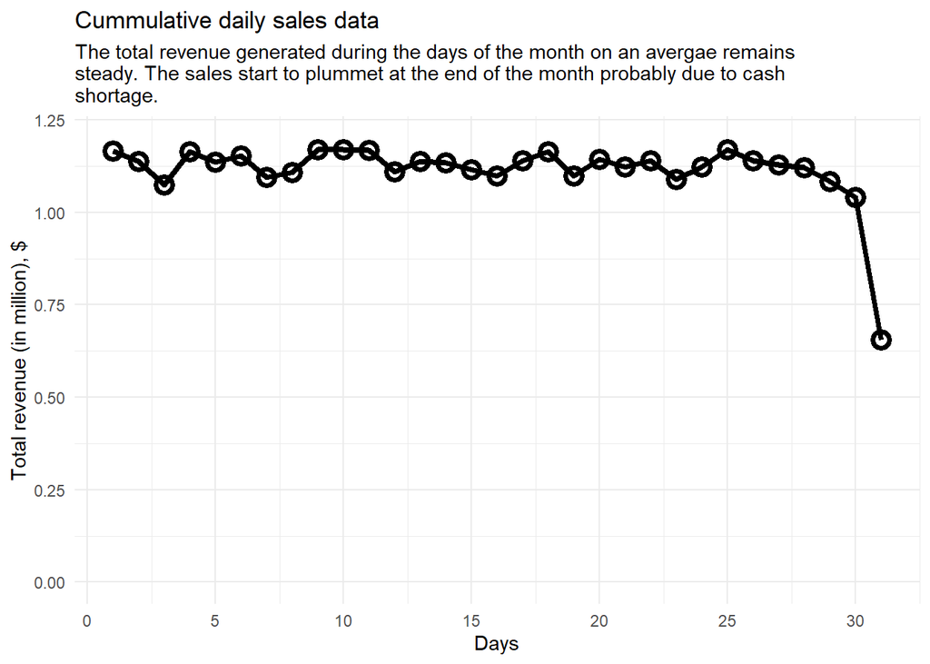

```r
sales_day %>% ggplot(aes(day, revenue/1e6)) +
  geom_point(size=3, shape=21, stroke=2)+
  geom_line(size=1.5)+
  xlab("Days") + ylab("Total revenue (in million), $") +
  scale_x_continuous(breaks=seq(0,31,5)) +
  scale_y_continuous(limits = c(0,1.2)) +
  labs(title = "Cummulative daily sales data",
       subtitle="The total revenue generated during the days of the month on an avergae remains \nsteady. The sales start to plummet at the end of the month probably due to cash \nshortage.") +
  theme_minimal()
```

Let us know check the frequency of orders.

```r
sales_daily_freq <- sales_new %>% group_by(month) %>% summarise(frequency = length(unique(`Order ID`)))
```

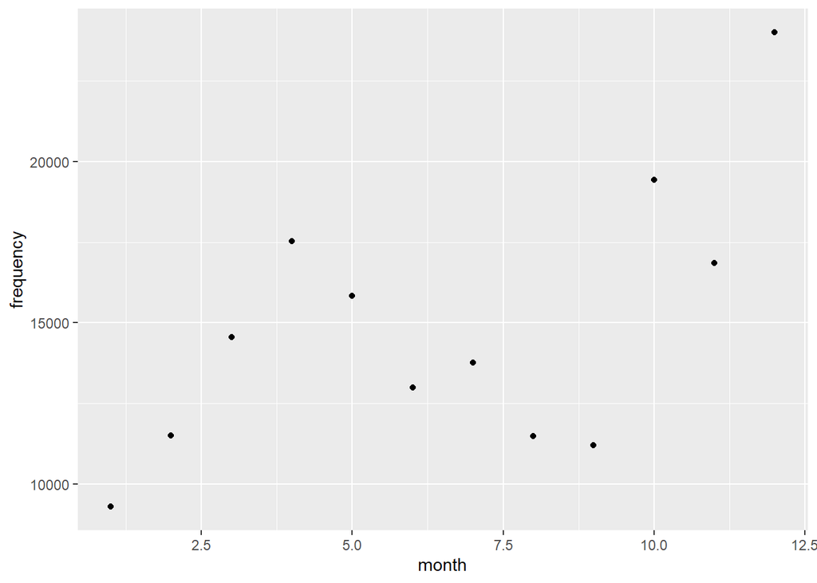

```r
sales_daily_freq %>% ggplot(aes(month,frequency))+geom_point()
```

### Day of the week when sales were made

[figure not shown]

```r
sales_new %>% mutate(week_day = wday(date)) %>% ggplot(aes(week_day,length(unique(week_day)))) +
  geom_point()+
  #geom_histogram(stat = "count",fill = "#E69F00", colour = "red") +
  labs(x = "Days of the week", y = "# of orders") +
  theme_minimal(base_size = 12)
```

### Time of the day when sales were made

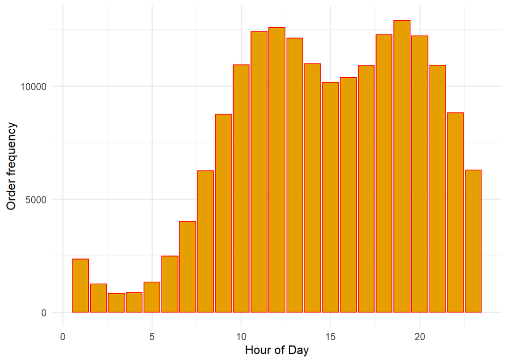

```r
sales_new %>% ggplot(aes(hour(hms(time)))) +
  geom_histogram(stat = "count",fill = "#E69F00", colour = "red") +
  labs(x = "Hour of Day", y = "Order frequency") +
  theme_minimal(base_size = 12)
```

This can help us tell the time for sales and promotions to increase the sales.

## Best selling product

```r
sales_product <- sales_new %>%
  group_by(Product) %>%
  summarise(revenue = sum(`Price Each`*`Quantity Ordered`)) %>%
  arrange(desc(revenue)) %>% mutate(percent = round(revenue*100/sum(revenue),2))

datatable(sales_product)
```

|  | Product | revenue | percent |
| --- | --- | --- | --- |
| 1 | Macbook Pro Laptop | 8037600 | 23.3 |
| 2 | iPhone | 4794300 | 13.9 |
| 3 | ThinkPad Laptop | 4129958.7 | 11.97 |
| 4 | Google Phone | 3319200 | 9.62 |
| 5 | 27in 4K Gaming Monitor | 2435097.56 | 7.06 |
| 6 | 34in Ultrawide Monitor | 2355558.01 | 6.83 |
| 7 | Apple Airpods Headphones | 2349150 | 6.81 |
| 8 | Flatscreen TV | 1445700 | 4.19 |
| 9 | Bose SoundSport Headphones | 1345565.43 | 3.9 |
| 10 | 27in FHD Monitor | 1132424.5 | 3.28 |

[output cut: 9 more lines]

### Individual quantity of products

```r
quantity_product <- sales_new %>%
  group_by(Product) %>%
  summarise(quantity = sum(`Quantity Ordered`)) %>%
  arrange(desc(quantity))

datatable(quantity_product)
```

|  | Product | quantity |
| --- | --- | --- |
| 1 | AAA Batteries (4-pack) | 31017 |
| 2 | AA Batteries (4-pack) | 27635 |
| 3 | USB-C Charging Cable | 23975 |
| 4 | Lightning Charging Cable | 23217 |
| 5 | Wired Headphones | 20557 |
| 6 | Apple Airpods Headphones | 15661 |
| 7 | Bose SoundSport Headphones | 13457 |
| 8 | 27in FHD Monitor | 7550 |
| 9 | iPhone | 6849 |
| 10 | 27in 4K Gaming Monitor | 6244 |

[output cut: 9 more lines]

There are 19 unique products for sale. The best seller is Macbook Pro Laptop.

### Monthly best seller

```r
sales_product_monthly <- sales_new %>%
  group_by(month,Product) %>%
  summarise(revenue = sum(`Price Each`*`Quantity Ordered`)) %>%
  arrange(desc(revenue)) %>% filter(revenue == max(revenue))
datatable(sales_product_monthly)
```

|  | month | Product | revenue |
| --- | --- | --- | --- |
| 1 | 12 | Macbook Pro Laptop | 1093100 |
| 2 | 10 | Macbook Pro Laptop | 892500 |
| 3 | 5 | Macbook Pro Laptop | 790500 |
| 4 | 4 | Macbook Pro Laptop | 771800 |
| 5 | 11 | Macbook Pro Laptop | 748000 |
| 6 | 3 | Macbook Pro Laptop | 644300 |
| 7 | 7 | Macbook Pro Laptop | 625600 |
| 8 | 6 | Macbook Pro Laptop | 605200 |
| 9 | 8 | Macbook Pro Laptop | 508300 |
| 10 | 9 | Macbook Pro Laptop | 489600 |

[output cut: 2 more lines]

Each month Macbook Pro laptop was the best seller.

## Unique invoices

```r
sales_invoices <- sales_new %>%
  group_by(month) %>%
  summarise(n_invoices = length(unique(`Order ID`))) %>%
  arrange()

datatable(sales_invoices)
```

|  | month | n_invoices |
| --- | --- | --- |
| 1 | 1 | 9293 |
| 2 | 2 | 11496 |
| 3 | 3 | 14549 |
| 4 | 4 | 17528 |
| 5 | 5 | 15836 |
| 6 | 6 | 12989 |
| 7 | 7 | 13761 |
| 8 | 8 | 11484 |
| 9 | 9 | 11202 |
| 10 | 10 | 19436 |

[output cut: 2 more lines]

## Calculating state statistics

```r
state = state.abb

total = vector()
unique = vector()

for (i in 1:length(state)) {
  total[i] = length((grep(state[i],sales_new$`Purchase Address`, value = TRUE)))
  unique[i] = length(unique(grep(state[i],sales_new$`Purchase Address`, value = TRUE)))
}

sales_state = data.frame(state,total,unique)
```

```r
# only keeping the non-zero values

sales_state <- sales_state %>% filter(unique != 0) %>% arrange(desc(total))

datatable(sales_state)
```

|  | state | total | unique |
| --- | --- | --- | --- |
| 1 | CA | 74337 | 49774 |
| 2 | NY | 24876 | 18807 |
| 3 | TX | 24725 | 20930 |
| 4 | MA | 19934 | 15706 |
| 5 | GA | 14881 | 12334 |
| 6 | WA | 14732 | 12212 |
| 7 | OR | 10010 | 8723 |
| 8 | ME | 2455 | 2301 |

```r
sales_state_city <- sales_new %>%
  mutate(state = str_split_fixed(ex_city_state(`Purchase Address`),",",n=2)[,2],
         city = str_split_fixed(ex_city_state(`Purchase Address`),",",n=2)[,1],
         revenue = `Quantity Ordered`*`Price Each`) %>%
  select(-c(2:10))
```

```r
sales_state <- sales_state_city %>% group_by(state) %>%
  summarise(total = length(`Order ID`), unique = length(unique(`Order ID`)), revenue=sum(revenue))%>%
  arrange(desc(revenue))

datatable(sales_state)
```

|  | state | total | unique | revenue |
| --- | --- | --- | --- | --- |
| 1 | CA | 74337 | 71396 | 13714774.71 |
| 2 | NY | 24876 | 23848 | 4664317.43 |
| 3 | TX | 24725 | 23749 | 4587557.15 |
| 4 | MA | 19934 | 19092 | 3661642.01 |
| 5 | GA | 14881 | 14253 | 2795498.58 |
| 6 | WA | 14732 | 14119 | 2747755.48 |
| 7 | OR | 10010 | 9617 | 1870732.34 |
| 8 | ME | 2455 | 2363 | 449758.27 |

```r
sales_city <- sales_state_city %>% group_by(city) %>%
  summarise(total = length(`Order ID`), unique = length(unique(`Order ID`)), revenue = sum(revenue))%>%
  arrange(desc(revenue))

datatable(sales_city)
```

|  | city | total | unique | revenue |
| --- | --- | --- | --- | --- |
| 1 | San Francisco | 44732 | 42898 | 8262203.91 |
| 2 | Los Angeles | 29605 | 28498 | 5452570.8 |
| 3 | New York City | 24876 | 23848 | 4664317.43 |
| 4 | Boston | 19934 | 19092 | 3661642.01 |
| 5 | Atlanta | 14881 | 14253 | 2795498.58 |
| 6 | Dallas | 14820 | 14240 | 2767975.4 |
| 7 | Seattle | 14732 | 14119 | 2747755.48 |
| 8 | Portland | 12465 | 11980 | 2320490.61 |
| 9 | Austin | 9905 | 9509 | 1819581.75 |

## Products sold together

```r
buying_pattern <- inner_join(sales_new, sales_new, by = 'Order ID') %>%
  filter(Product.x < Product.y) %>%
  count(Product.x, Product.y) %>%
  arrange(desc(n))

datatable(buying_pattern)
```

|  | Product.x | Product.y | n |
| --- | --- | --- | --- |
| 1 | iPhone | Lightning Charging Cable | 1015 |
| 2 | Google Phone | USB-C Charging Cable | 999 |
| 3 | iPhone | Wired Headphones | 462 |
| 4 | Google Phone | Wired Headphones | 423 |
| 5 | Apple Airpods Headphones | iPhone | 373 |
| 6 | USB-C Charging Cable | Vareebadd Phone | 368 |
| 7 | Bose SoundSport Headphones | Google Phone | 228 |
| 8 | USB-C Charging Cable | Wired Headphones | 205 |
| 9 | Vareebadd Phone | Wired Headphones | 149 |
| 10 | Lightning Charging Cable | Wired Headphones | 129 |

[output cut: 149 more lines]

## References

1. https://www.youtube.com/watch?v=eMOA1pPVUc4
2. https://www.tidyverse.org/